# ST661: Assignment 2

Nishant kumar

30 October, 2019

#### Question 1

a.Download the cdc1.Rdata file from moodle and load with load(“cdc1.Rdata”) # or if you are working on the Rstudio server load(“rstudio_files/ST661/cdc1.Rdata”) which gives a dataset called cdc1, a subset of the data used in class. (a) Change exerany, smoke100 and hlthplan to be factors with suitable levels.

```r
load("cdc1.Rdata")
head(cdc1)
```

```
##         genhlth exerany hlthplan smoke100 height weight wtdesire age
## 5752       good       1        1        1     66    160      155  72
## 15766      fair       1        1        1     60    148      118  80
## 8179       fair       0        1        0     65    173      170  48
## 17658 very good       0        1        1     72    195      180  50
## 18806      good       1        1        0     67    165      135  35
## 911   excellent       1        1        0     60    103      103  33
##       gender
## 5752       m
## 15766      f
## 8179       m
## 17658      m
## 18806      f
## 911        f
```

```r
cdc1$exerany<-as.factor(cdc1$exerany)
cdc1$exerany
```

```
##   [1] 1 1 0 0 1 1 1 0 0 1 1 1 1 1 1 1 1 1 1 0 1 0 1 0 1 1 1 1 1 1 0 1 0 0 1
##  [36] 1 0 1 1 1 1 0 1 1 1 0 0 1 1 0 1 1 0 1 0 1 1 1 1 1 1 1 1 1 1 1 1 1 0 1
##  [71] 1 1 0 1 1 0 1 1 1 1 1 0 0 1 1 0 1 0 1 1 1 0 0 1 0 1 1 1 1 1 0 1 0 1 1
## [106] 0 1 0 1 1 1 1 1 1 1 1 1 1 1 1 1 1 0 1 0 1 1 1 1 1 1 0 1 1 1 0 1 1 1 1
## [141] 0 1 1 0 0 1 1 1 1 1 1 1 1 0 1 1 1 1 1 1 1 0 1 1 0 1 1 1 1 1 1 1 1 1 1
## [176] 1 1 1 1 1 0 0 1 1 1 1 0 0 1 1 1 1 1 1 1 1 0 1 1 1 0 1 1 1 1 1 1 1 0 1
## [211] 0 1 1 1 1 0 1 1 1 1
## Levels: 0 1
```

```r
levels(cdc1$exerany) <- c("no", "yes")
cdc1$exerany
```

```
##   [1] yes yes no  no  yes yes yes no  no  yes yes yes yes yes yes yes yes
##  [18] yes yes no  yes no  yes no  yes yes yes yes yes yes no  yes no  no
##  [35] yes yes no  yes yes yes yes no  yes yes yes no  no  yes yes no  yes
##  [52] yes no  yes no  yes yes yes yes yes yes yes yes yes yes yes yes yes
##  [69] no  yes yes yes no  yes yes no  yes yes yes yes yes no  no  yes yes
##  [86] no  yes no  yes yes yes no  no  yes no  yes yes yes yes yes no  yes
## [103] no  yes yes no  yes no  yes yes yes yes yes yes yes yes yes yes yes
## [120] yes yes yes no  yes no  yes yes yes yes yes yes no  yes yes yes no
## [137] yes yes yes yes no  yes yes no  no  yes yes yes yes yes yes yes yes
## [154] no  yes yes yes yes yes yes yes no  yes yes no  yes yes yes yes yes
## [171] yes yes yes yes yes yes yes yes yes yes no  no  yes yes yes yes no
## [188] no  yes yes yes yes yes yes yes yes no  yes yes yes no  yes yes yes
## [205] yes yes yes yes no  yes no  yes yes yes yes no  yes yes yes yes
## Levels: no yes
```

```r
cdc1$hlthplan<-as.factor(cdc1$hlthplan)
levels(cdc1$hlthplan) <- c("no", "yes")
cdc1$hlthplan
```

```
##   [1] yes yes yes yes yes yes yes yes yes yes yes yes yes no  yes no  no
##  [18] yes yes no  yes yes yes yes yes no  yes no  yes yes yes yes yes yes
##  [35] yes yes yes yes yes yes yes yes yes yes no  yes yes yes yes yes yes
##  [52] yes no  yes yes yes yes yes yes yes yes yes yes yes no  yes yes yes
##  [69] yes yes yes yes yes no  yes yes no  yes yes yes yes yes yes yes yes
##  [86] yes yes yes yes yes yes yes yes yes yes yes yes yes yes yes yes yes
## [103] yes yes yes no  yes yes yes yes yes yes yes yes yes yes yes yes yes
## [120] yes yes yes yes yes yes yes yes yes yes yes yes no  yes yes yes yes
## [137] yes yes yes yes yes no  yes yes yes yes yes yes yes yes yes yes yes
## [154] yes yes yes yes yes yes yes yes no  yes yes yes yes no  yes yes yes
## [171] yes yes yes yes yes yes yes yes yes no  yes no  yes yes yes yes yes
## [188] yes no  yes yes yes no  yes yes yes yes yes yes yes no  yes yes yes
## [205] yes yes yes yes yes yes yes yes yes yes yes yes yes yes yes yes
## Levels: no yes
```

```r
cdc1$smoke100<-as.factor(cdc1$smoke100)
levels(cdc1$smoke100) <- c("no", "yes")
cdc1$smoke100
```

```
##   [1] yes yes no  yes no  no  no  yes yes no  yes no  no  no  no  no  yes
##  [18] yes yes no  yes no  yes no  yes yes no  yes yes no  no  no  yes yes
##  [35] yes no  yes no  yes no  yes no  no  yes no  yes no  yes no  no  yes
##  [52] no  yes no  no  no  yes no  no  no  no  no  yes yes yes yes yes yes
##  [69] yes no  yes yes no  yes no  no  yes no  no  yes no  yes no  no  no
##  [86] no  yes no  no  no  no  yes no  yes yes no  no  no  yes yes no  no
## [103] yes no  no  no  yes yes no  yes yes no  no  no  yes no  yes no  yes
## [120] no  yes no  yes no  yes yes yes yes yes no  no  no  no  no  yes no
## [137] yes no  yes no  no  no  no  no  no  no  yes yes no  no  yes yes no
## [154] no  yes no  yes yes no  yes yes no  no  no  yes yes yes yes no  yes
## [171] no  yes yes yes no  yes no  no  no  no  yes yes no  yes yes no  yes
## [188] no  no  yes no  no  no  yes no  no  yes no  no  no  no  yes yes no
## [205] no  yes no  no  yes no  no  no  no  yes yes yes no  yes no  yes
## Levels: no yes
```

b.Calculate the proportion of men that have health very good or better. Do the same for women. Who has the better health?

```r
hlth<-prop.table(xtabs(~genhlth+gender,data=cdc1),2)
hlth
```

```
##            gender
## genhlth              m          f
##   excellent 0.27027027 0.27522936
##   very good 0.37837838 0.30275229
##   good      0.24324324 0.26605505
##   fair      0.09009009 0.12844037
##   poor      0.01801802 0.02752294
```

```r
men_very_good_better<-(hlth[1,1]+hlth[2,1])
men_vgood_better_percent<-(men_very_good_better)*100
men_vgood_better_percent
```

```
## [1] 64.86486
```

```r
female_very_good_better<-(hlth[1,2]+hlth[2,2])
female_very_good_better_percent<-(female_very_good_better)*100
female_very_good_better_percent
```

```
## [1] 57.79817
```

c.Use subset to extract the smokers. For the smokers, calculate the proportion of men that have health very good or better. Do the same for women.

```r
smoke<-subset(cdc1,cdc1$smoke100=='yes')
smoke
```

```
##         genhlth exerany hlthplan smoke100 height weight wtdesire age
## 5752       good     yes      yes      yes     66    160      155  72
## 15766      fair     yes      yes      yes     60    148      118  80
## 17658 very good      no      yes      yes     72    195      180  50
## 17843      good      no      yes      yes     65    130      120  39
## 11025      good      no      yes      yes     76    290      230  53
## 19128 very good     yes      yes      yes     66    150      150  56
## 4918       fair     yes       no      yes     62    290      160  23
## 841   excellent     yes      yes      yes     63    115      113  52
## 6553  very good     yes      yes      yes     61    140      135  87
## 17773 very good     yes      yes      yes     62    115      110  33
## 12797 very good     yes      yes      yes     74    205      195  55
## 13099      good     yes      yes      yes     65    150      140  41
## 14153 very good     yes       no      yes     71    160      130  19
## 11867      good     yes       no      yes     70    180      170  48
```

[output cut: 185 more lines]

```r
smoke_table<-prop.table(xtabs(~genhlth+gender,data=smoke),2)
prop_men<-smoke_table[1,1]+smoke_table[2,1]
prop_men
```

```
## [1] 0.6
```

```r
prop_female<-smoke_table[1,2]+smoke_table[2,2]
prop_female
```

```
## [1] 0.5454545
```

d.Repeat (c) for non smokers

```r
non_smoke<-subset(cdc1,cdc1$smoke100=='no')
non_smoke
```

```
##         genhlth exerany hlthplan smoke100 height weight wtdesire age
## 8179       fair      no      yes       no     65    173      170  48
## 18806      good     yes      yes       no     67    165      135  35
## 911   excellent     yes      yes       no     60    103      103  33
## 10559      good     yes      yes       no     63    156      140  80
## 9129  very good     yes      yes       no     67    134      139  29
## 9062  excellent     yes      yes       no     64    120      120  47
## 13544 excellent     yes      yes       no     78    200      200  28
## 11446      good     yes       no       no     68    175      150  36
## 2058       good     yes      yes       no     65    127      125  57
## 17984      good     yes       no       no     73    235      210  33
## 19072 very good      no       no       no     64    194      130  22
## 13842      good      no      yes       no     59    130      110  36
## 19863      fair      no      yes       no     53    125       95  38
## 10868 excellent     yes      yes       no     65    120      116  35
```

[output cut: 229 more lines]

```r
non_smoke_table<-prop.table(xtabs(~genhlth+gender,data=non_smoke),2)
prop_men<-non_smoke_table[1,1]+non_smoke_table[2,1]
prop_men
```

```
## [1] 0.6964286
```

```r
prop_female<-non_smoke_table[1,2]+non_smoke_table[2,2]
prop_female
```

```
## [1] 0.6
```

5. Based on your calculations of (c) and (d), compare the health of men and women, and the health of smokers and non smokers.

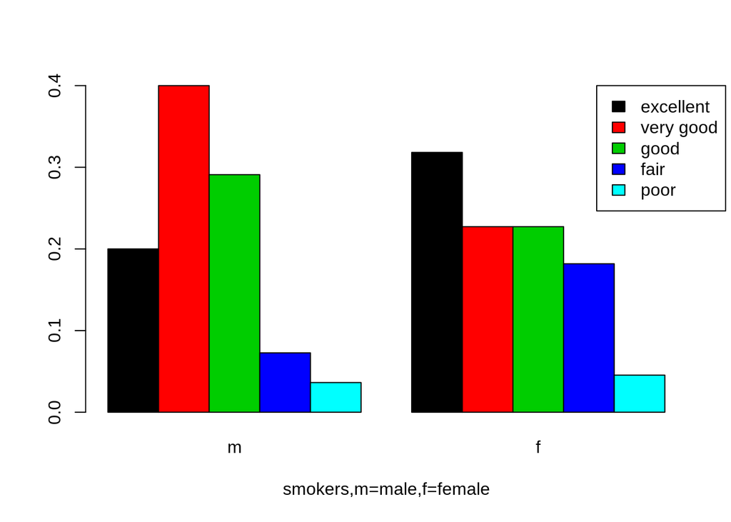

```r
#smokers (c)
# men vs women

barplot(smoke_table,xlab = "smokers,m=male,f=female",beside=TRUE,col = c(1:5),legend.text = TRUE,args.legend =(list(x=13.2,y=.4)))
```

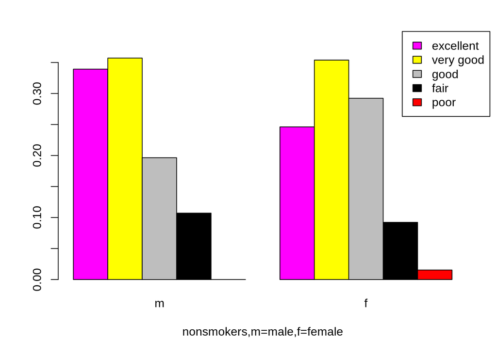

```r
#smokers (d)
# men vs women
barplot(non_smoke_table,xlab = "nonsmokers,m=male,f=female",beside=TRUE,col = c(6:10),legend.text = TRUE,args.legend =(list(x=13.1,y=.4)))
```

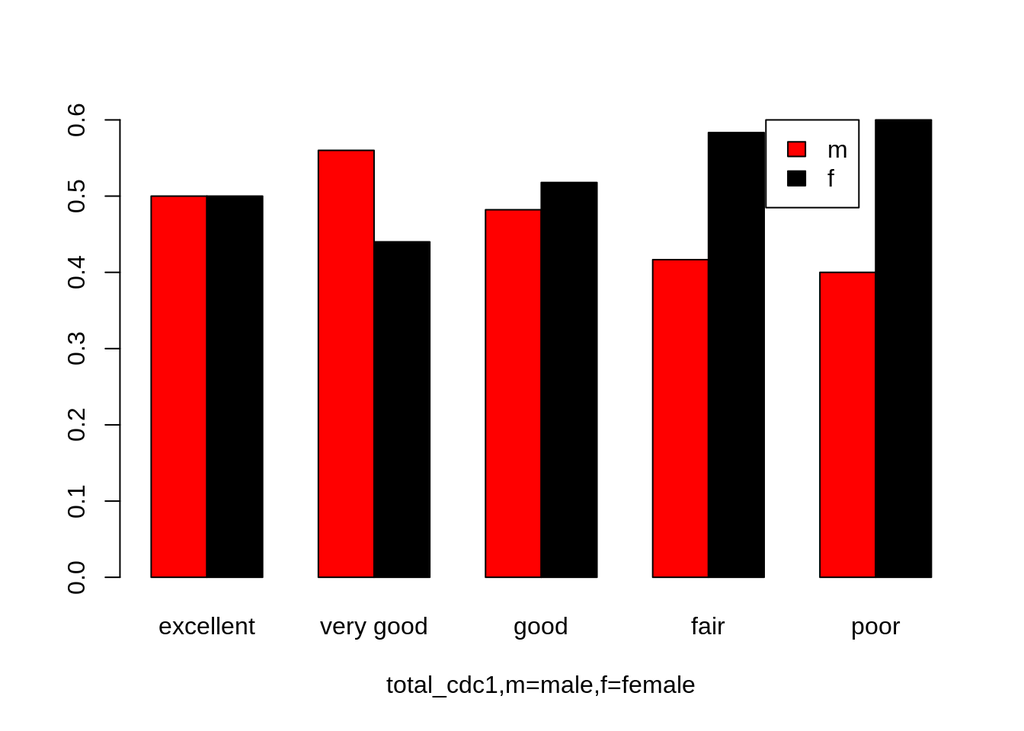

```r
#overall
# men vs women
total_men_women_hlth<-t(prop.table(xtabs(~genhlth+gender,data=cdc1),1))
barplot(total_men_women_hlth,xlab = "total_cdc1,m=male,f=female",beside=TRUE,col = c("red","black"),legend.text = TRUE,args.legend =(list(x=13.7,y=.6)))
```

```r
skew<-function(x){
n<-sum(x==x)
m3<-sum((x-mean(x))^3)/n
m2<-sum((x-mean(x))^2)/n
comp<-m3/(m2^(3/2))
return(comp)
}
skew
```

```
## function(x){
## n<-sum(x==x)
## m3<-sum((x-mean(x))^3)/n
## m2<-sum((x-mean(x))^2)/n
## comp<-m3/(m2^(3/2))
## return(comp)
## }
```

b.Test your function on mtcars$wt .

```r
skew(mtcars$wt)
```

```
## [1] 0.4437855
```

c.Test it also on a set of 50 numbers generated from the standard normal distribution.

```r
p2<-rnorm(50,mean=0,sd=1)
a1<-skew(p2)
a1
```

```
## [1] 0.312276
```

d.Using replicate, replicate the calculation of (c) 1000 times. Draw a histogram of the results and calculate the mean skewness value.

```r
n1<-1000
rep<-replicate(n1,{p2<-rnorm(50,mean=0,sd=1)
skew(p2)})
mean(rep)
```

```
## [1] -0.006692666
```